# QES Multi Factor Analysis

This examples illustrates multi-factor analysis using analytics library. It shows the following steps:

- Downloading data from the platform
- Interfacing with the analytics library
- Neutralizing the factor
- Using different weighting schemes
  - Equi-weighted
  - Risk-parity weighting
  - Inverse-vol weighting
  - Specified weighting
- Portfolio Optimization

## Load Data Analytics and Machine Learning Libraries

```python
import numpy as np
import pandas as pd
import matplotlib.pyplot as plt
import seaborn as sns
from IPython.core.display import display, HTML
from pprint import pprint

#Preset parameters for plotting purposes
plt.rc('xtick', labelsize=16)
plt.rc('ytick', labelsize=16)
plt.rcParams["figure.figsize"] = (20,8)
plt.rcParams['legend.fontsize'] = 16
plt.rcParams.update({'font.size': 16})
sns.set_style("whitegrid")

prop_cycle = plt.rcParams['axes.prop_cycle']
colors = prop_cycle.by_key()['color']

display(HTML("<style>.container { width:80% !important; }</style>"))

#### ElasticNet library
import sklearn
from sklearn.linear_model import ElasticNet
print(" > sklearn version: {}".format(sklearn.__version__))

### XGBoost library
import xgboost as xgb

print(" > XGBoost version: {}".format(xgb.__version__))
```

```
 > sklearn version: 0.24.2
 > XGBoost version: 1.6.2
```

## Initializing the Data Query Engine using LQuant Database

```python
## lquant package library provides access to the data querying as well as analytics functions
try:
    from lquantPy import LQuant
    wq = LQuant.LQuant()                                       # wq is LQuant tool handler

except Exception as e:
    if str(e).startswith("VM is already running"):
        print ("LQuant is already initialized!")
    else:
        print (e)

#Please restart notebook and run this code block again in case there is an error
```

```
2022-08-31 13:44:32,902 - lquantPy.LQuant - INFO - Initial LQuant. This may take some time...
2022-08-31 13:44:32,903 - lquantPy.LQuant - INFO - Initialized LQuant environment
2022-08-31 13:44:32,903 - lquantPy.LQuant - INFO - Initializing LQuant, This will take some time....
```

```
Library Path -Djava.library.path=/usr/local/lib/R/site-library/rJava/jri
```

# Querying the data from LQuant

Lquant Query API allows access to several universes, factors (z-normal). The query api allows users to download data to memory and perform analytics. The data returned from lquant has three dimensions:

1. Factors (K)
2. Securities (N)
3. Dates (M)

Below example show querying 10 factors for 10 years at month end frequency.

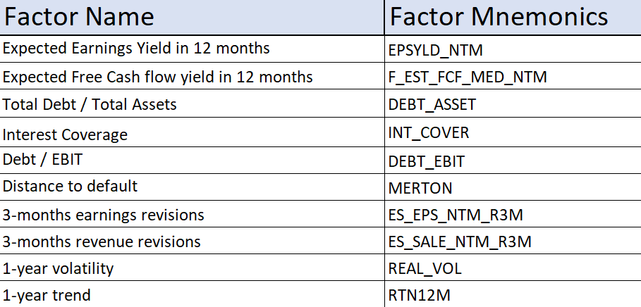

### Improve the factor coverage of Analyst Expectation factors

Certain Analyst Expectation factors may not have reasonable coverage and history. In order to address any potential coverage and history issues, we replace those expected factors with their realized counterpart (i.e. FY0) instead of expected (i.e. FY1).

```python
#Replace Actual instead of Expected
wq.define('CFOYLD_FY1_ADJ=nvl(CFOYLD_FY1, CFOYLD)')
wq.define('EPSYLD_NTM_ADJ=nvl(EPSYLD_NTM, EPSYLD_LTM_B)')

#Adjust Market Cap using FX Ratee
wq.define('LOG_MKTCAP_ADJ=log(MKTCAP_USD*FXRATE_USD)')

wq.factor_detail('CFOYLD_FY1_ADJ')
```

|  | Key | Value |
| --- | --- | --- |
| 0 | Mnemonic | CFOYLD_FY1_ADJ |
| 1 | Expression | nvl(CFOYLD_FY1, CFOYLD) |
| 2 | Function |  |
| 3 | Args |  |
| 4 | Description | nvl(CFOYLD_FY1, CFOYLD) |
| 5 | Unit | WHOLE |
| 6 | Is Value | No |
| 7 | Frequency |  |
| 8 | Adjustment Type | None |
| 9 | Fx Adjustment | No Adjustment |
| 10 | Staleness Threshold |  |